# Graded Novelty Encoding Task - art narrative analysis

# The paradigm

This is the GNET paradigm with an added narrative to improve immersion of the participants.

# Participants

The online task has been started a total of 118 times.

We excluded a total of 2 runs due to irregular data leaving 116 in the analysis.

We excluded some (1) runs as they missed more than 66 of 175 trials.

We also excluded 10 runs in which the participant produced less than 0.3 corrected recognition rate for familiars in the study phase.

Maybe responses [mean(±sd)] : 9.9438202 ± 9.2088884

The sample had a mean(±sd) age of 19.7738095 ± 1.6232586.

The sample contained 67 women.

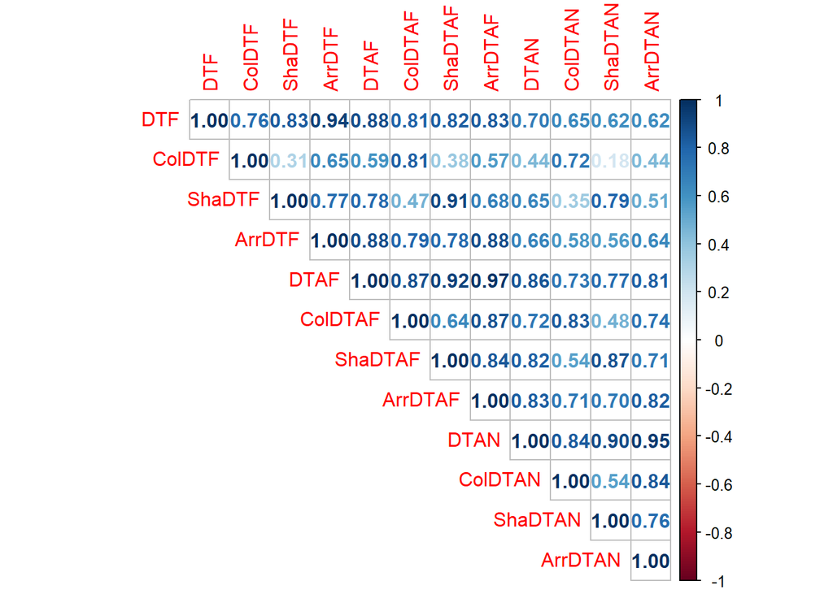

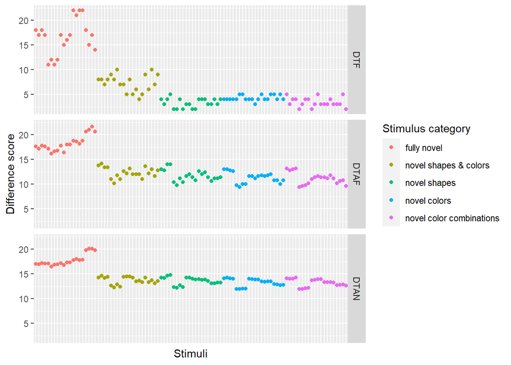

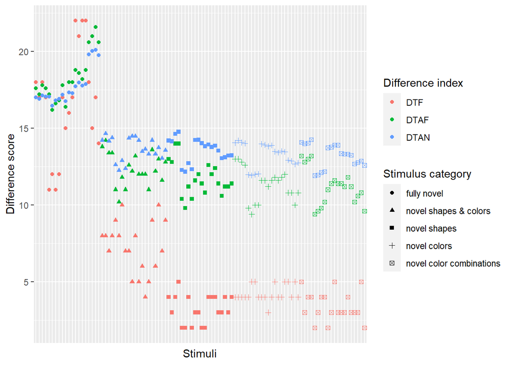

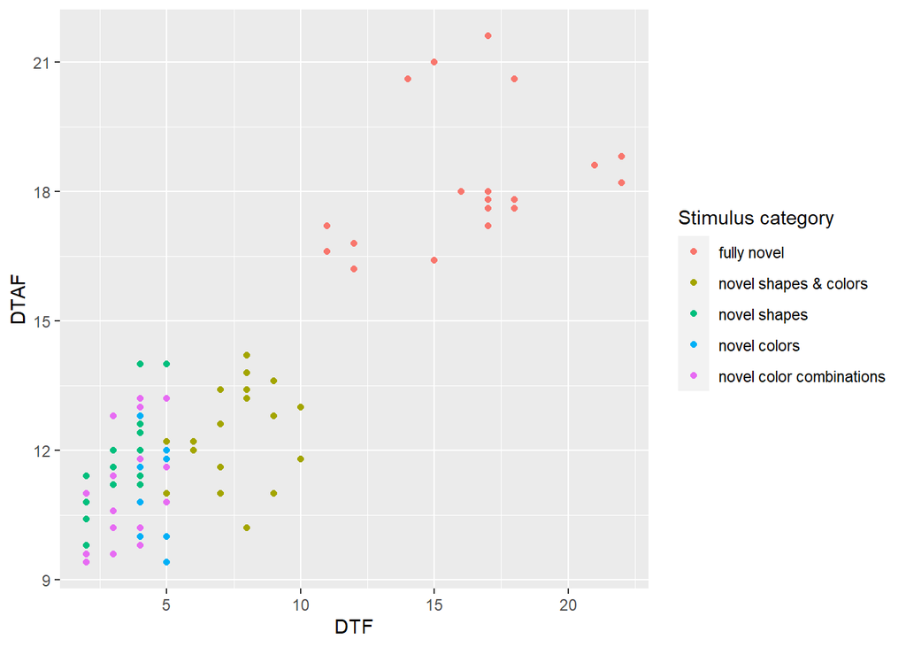

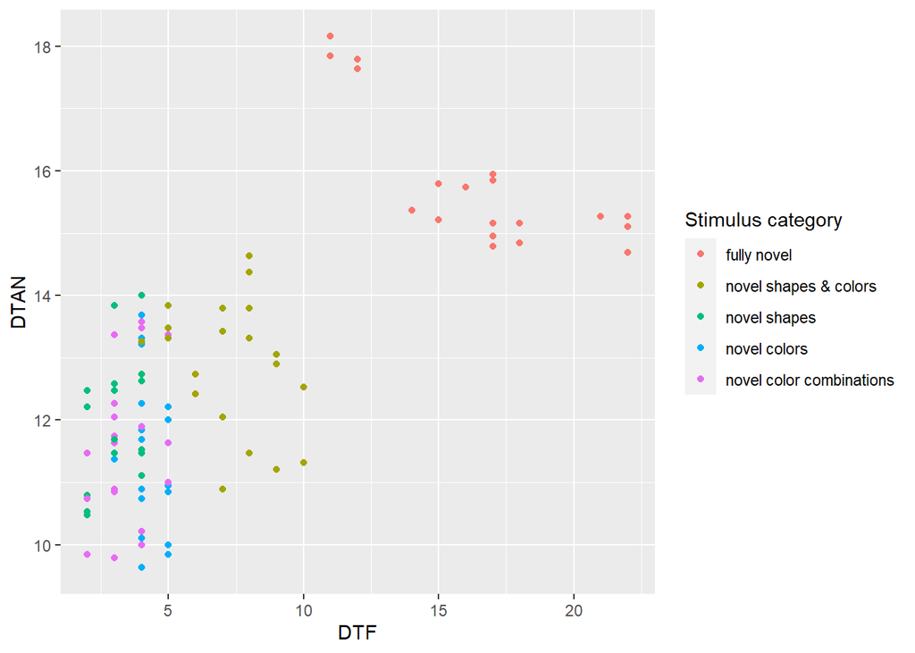

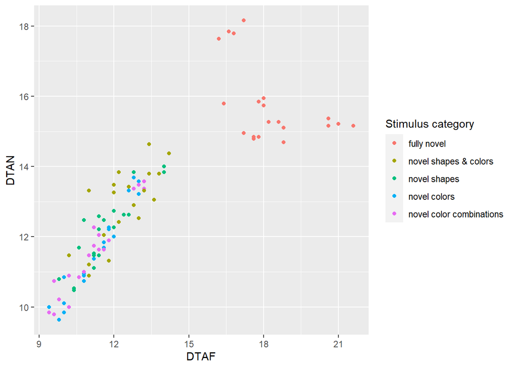

# Study phase:

During the study phase, the participants see familiar and novel items.

The participants produced a mean (±sd) recognition rate of 0.687619 ± 0.1588484 for familiar pictures.

The participants produced a mean (±sd) corrected recognition rate of 0.5740476 ± 0.1703796 for familiar pictures.

Uncorrected: The sample performed above chance levels, as a one sample t-test showed (t(83)=10.8251445, p = 7.6778543^{-18}, Cohen’s d = 1.1811201, 95% CI:0.7107705 - 1.6514697).

Corrected: The sample performed above chance levels, as a one sample t-test showed (t(83)=30.8794823, p = 1.421084^{-47}, Cohen’s d = 3.3692277, 95% CI:2.6941856 - 4.0442699).

We use an ANOVA to see if there is a difference in correct rejection for the different novels.

```
## Anova Table (Type 3 tests)
##
## Response: N
##   Effect           df  MSE         F  ges p.value
## 1   type 3.57, 295.90 1.61 10.83 *** .072   <.001
## ---
## Signif. codes:  0 '***' 0.001 '**' 0.01 '*' 0.05 '+' 0.1 ' ' 1
##
## Sphericity correction method: GG
```

```
##  contrast             estimate    SE df t.ratio p.value
##  diffarr - sarr         0.7143 0.138 83   5.169  <.0001
##  diffarr - sarrcol      0.7619 0.191 83   3.982  0.0013
##  diffarr - sarrsha      1.1905 0.178 83   6.687  <.0001
##  diffarr - sarrshacol   0.7738 0.161 83   4.807  0.0001
##  sarr - sarrcol         0.0476 0.204 83   0.234  0.9993
##  sarr - sarrsha         0.4762 0.174 83   2.738  0.0569
##  sarr - sarrshacol      0.0595 0.175 83   0.339  0.9971
##  sarrcol - sarrsha      0.4286 0.222 83   1.933  0.3081
##  sarrcol - sarrshacol   0.0119 0.199 83   0.060  1.0000
##  sarrsha - sarrshacol  -0.4167 0.191 83  -2.181  0.1971
##
## P value adjustment: tukey method for comparing a family of 5 estimates
```

```
##  contrast  estimate    SE df t.ratio p.value
##  linear      -2.024 0.384 83  -5.266  <.0001
##  quadratic    1.881 0.476 83   3.955  0.0002
##  cubic        0.179 0.365 83   0.489  0.6259
##  quartic      2.274 1.297 83   1.754  0.0832
```

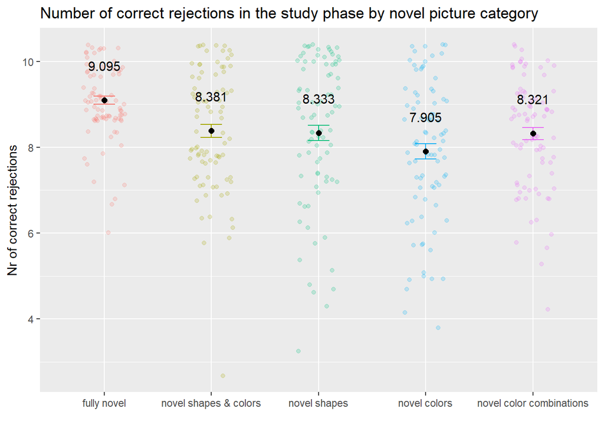

# Test phase:

This phase tests the learning that has occurred during the study phase. If the participants learned the novels in the study phase, their responses should differ for the stimuli that they have already seen during the study phase (familiars) and those that they see for the first time during the test phase (novels). We also let the participants to choose “maybe” by pressing the down arrow, but asked them not to overuse this response (maybe resp <= 50). We added these responses as correct responses to both stimulus categories.

Maybe responses (MEAN ± SD): 10.2380952 ± 9.36363.

```
## [1] "A t-test to compare the number of old responses btwn old and new stim"
```

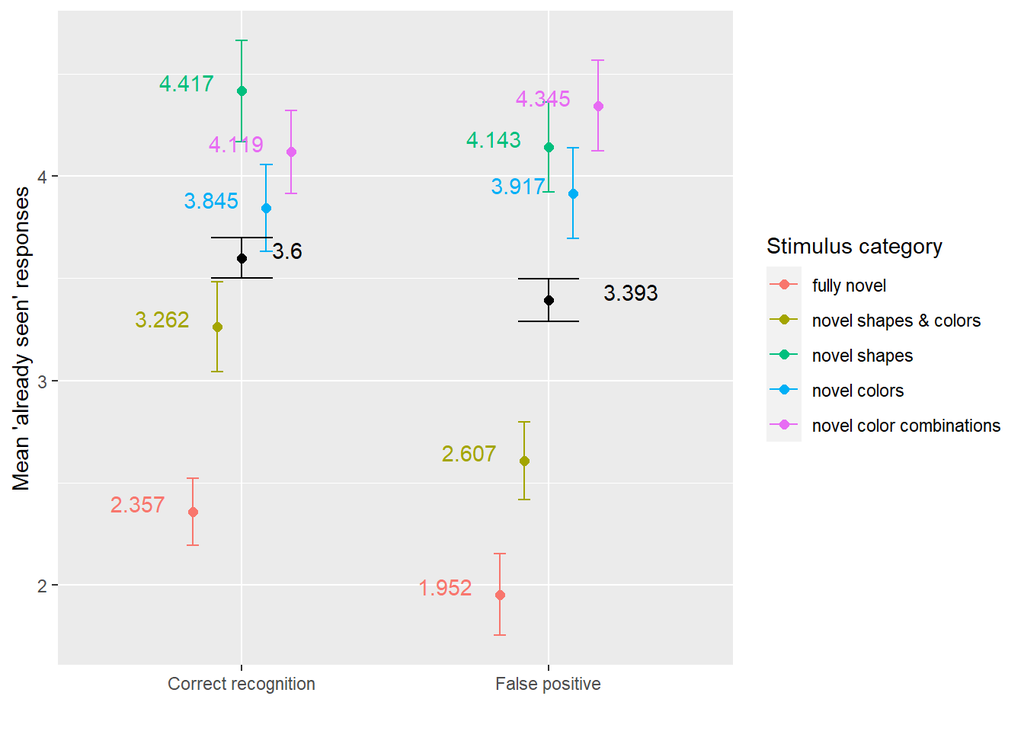

Results of the paired t-test: (t(419)=2.1717451, p = 0.0304352, Cohen’s d = 0.098617, 95% CI:0.0092716 - 0.1879624).

Shapiro-Wilk is significant (p = 7.3416954^{-7}).

We used a Wilcoxon sgined-rank test. Z = -1.8971113, p = 0.0289066

## ANOVA - Corrected Recog

```
## Anova Table (Type 3 tests)
##
## Response: CorrRecog
##     Effect           df  MSE      F  ges p.value
## 1 neworder 3.81, 316.42 3.59 3.12 * .027    .017
## ---
## Signif. codes:  0 '***' 0.001 '**' 0.01 '*' 0.05 '+' 0.1 ' ' 1
##
## Sphericity correction method: GG
```

```
##  contrast estimate    SE df t.ratio p.value
##  A - B      -0.250 0.251 83  -0.995  0.8567
##  A - C       0.476 0.263 83   1.809  0.3753
##  A - D       0.131 0.249 83   0.526  0.9844
##  A - E       0.631 0.295 83   2.141  0.2129
##  B - C       0.726 0.284 83   2.561  0.0873
##  B - D       0.381 0.288 83   1.323  0.6776
##  B - E       0.881 0.302 83   2.915  0.0360
##  C - D      -0.345 0.302 83  -1.144  0.7827
##  C - E       0.155 0.311 83   0.498  0.9873
##  D - E       0.500 0.303 83   1.649  0.4710
##
## P value adjustment: tukey method for comparing a family of 5 estimates
```

```
##  contrast  estimate    SE df t.ratio p.value
##  linear      -1.643 0.653 83  -2.515  0.0138
##  quadratic   -0.429 0.712 83  -0.602  0.5486
##  cubic        0.131 0.650 83   0.202  0.8407
##  quartic     -3.964 1.715 83  -2.311  0.0233
```

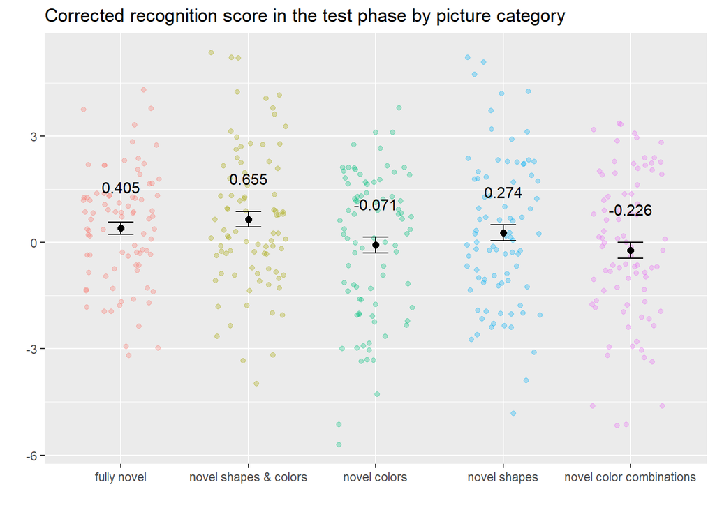

ANOVA (factor: TYPE (5 lvls)): (F[3.812289,316.4199863] = 3.1231082, p = 0.0169159, n2G = 0.0267188).

# Mixed models

The metrics

-DTF - Difference To corresponding Familiar picture All pictures are compared to a familiar. The number of differences between the three vectors of the pictures yields a difference score.

-DTAF - mean Difference To All Familiars We calculate the difference from all prototypes and take the mean for each picture in the set.

-DTN - mean Difference To all other Novels in the same category We calculate the differences between each pair of pictures and then take the mean of these differences (19 comparisons per stim).

## Study phase

With these models i tried to assess which difference index explains familiar v novel distinction in study phase the best. As far as i understand, the model with the smallest AIC fits best to our data, which means that the mean difference from the corresponding familiar worked best here. The models all show, that the more different pictures are categorized with the highest efficacy.

```
## Generalized linear mixed model fit by maximum likelihood (Laplace
##   Approximation) [glmerMod]
##  Family: binomial  ( logit )
## Formula: st_corr ~ DTF + (1 | multichar_knowresp)
##    Data: stlmm
##
##      AIC      BIC   logLik deviance df.resid
##   6147.4   6167.6  -3070.7   6141.4     6297
##
## Scaled residuals:
##     Min      1Q  Median      3Q     Max
## -6.5545  0.1999  0.4453  0.5682  0.9813
##
## Random effects:
##  Groups             Name        Variance Std.Dev.
##  multichar_knowresp (Intercept) 0.1827   0.4274
## Number of obs: 6300, groups:  multichar_knowresp, 84
##
## Fixed effects:
##             Estimate Std. Error z value Pr(>|z|)
## (Intercept) 0.936512   0.062093   15.08   <2e-16 ***
## DTF         0.119536   0.008551   13.98   <2e-16 ***
## ---
## Signif. codes:  0 '***' 0.001 '**' 0.01 '*' 0.05 '.' 0.1 ' ' 1
##
## Correlation of Fixed Effects:
##     (Intr)
## DTF -0.394
```

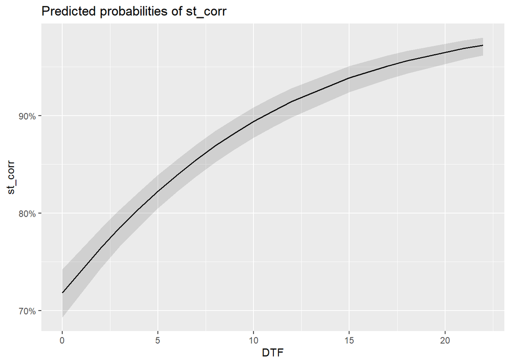

```
## Generalized linear mixed model fit by maximum likelihood (Laplace
##   Approximation) [glmerMod]
##  Family: binomial  ( logit )
## Formula: st_corr ~ DTAF + (1 | multichar_knowresp)
##    Data: stlmm
##
##      AIC      BIC   logLik deviance df.resid
##   6160.8   6181.0  -3077.4   6154.8     6297
##
## Scaled residuals:
##     Min      1Q  Median      3Q     Max
## -4.1922  0.2979  0.4051  0.5390  1.0616
##
## Random effects:
##  Groups             Name        Variance Std.Dev.
##  multichar_knowresp (Intercept) 0.1847   0.4298
## Number of obs: 6300, groups:  multichar_knowresp, 84
##
## Fixed effects:
##             Estimate Std. Error z value Pr(>|z|)
## (Intercept)  0.78300    0.06620   11.83   <2e-16 ***
## DTAF         0.07679    0.00492   15.61   <2e-16 ***
## ---
## Signif. codes:  0 '***' 0.001 '**' 0.01 '*' 0.05 '.' 0.1 ' ' 1
##
## Correlation of Fixed Effects:
##      (Intr)
## DTAF -0.500
```

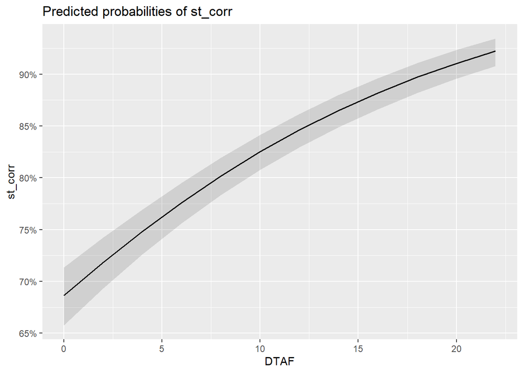

```
## Generalized linear mixed model fit by maximum likelihood (Laplace
##   Approximation) [glmerMod]
##  Family: binomial  ( logit )
## Formula: st_corr ~ DTAN + (1 | multichar_knowresp)
##    Data: stlmm
##
##      AIC      BIC   logLik deviance df.resid
##   6194.1   6214.3  -3094.0   6188.1     6297
##
## Scaled residuals:
##     Min      1Q  Median      3Q     Max
## -4.2472  0.3190  0.4106  0.5367  1.0454
##
## Random effects:
##  Groups             Name        Variance Std.Dev.
##  multichar_knowresp (Intercept) 0.1823   0.4269
## Number of obs: 6300, groups:  multichar_knowresp, 84
##
## Fixed effects:
##             Estimate Std. Error z value Pr(>|z|)
## (Intercept) 0.806524   0.066515   12.13   <2e-16 ***
## DTAN        0.073210   0.004973   14.72   <2e-16 ***
## ---
## Signif. codes:  0 '***' 0.001 '**' 0.01 '*' 0.05 '.' 0.1 ' ' 1
##
## Correlation of Fixed Effects:
##      (Intr)
## DTAN -0.515
```

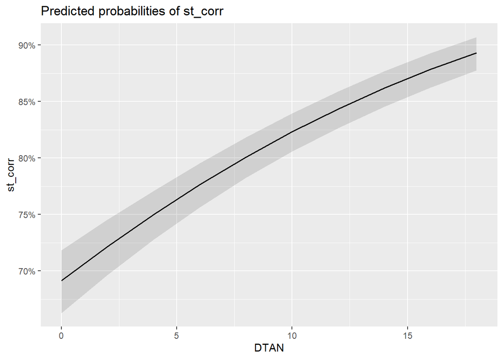

|  | st_corr |  |  |  | st_corr |  |  |  | st_corr |  |  |  |
| --- | --- | --- | --- | --- | --- | --- | --- | --- | --- | --- | --- | --- |
| Predictors | Log-Odds | std. Error | CI | p | Log-Odds | std. Error | CI | p | Log-Odds | std. Error | CI | p |
| (Intercept) | 0.94 | 0.06 | 0.81 – 1.06 | **<0.001** | 0.78 | 0.07 | 0.65 – 0.91 | **<0.001** | 0.81 | 0.07 | 0.68 – 0.94 | **<0.001** |
| DTF | 0.12 | 0.01 | 0.10 – 0.14 | **<0.001** |  |  |  |  |  |  |  |  |
| DTAF |  |  |  |  | 0.08 | 0.00 | 0.07 – 0.09 | **<0.001** |  |  |  |  |
| DTAN |  |  |  |  |  |  |  |  | 0.07 | 0.00 | 0.06 – 0.08 | **<0.001** |
| Random Effects |  |  |  |  |  |  |  |  |  |  |  |  |
| σ<sup>2</sup> | 3.29 |  |  |  | 3.29 |  |  |  | 3.29 |  |  |  |
| τ<sub>00</sub> | 0.18 <sub>multichar_knowresp</sub> |  |  |  | 0.18 <sub>multichar_knowresp</sub> |  |  |  | 0.18 <sub>multichar_knowresp</sub> |  |  |  |
| ICC | 0.05 |  |  |  | 0.05 |  |  |  | 0.05 |  |  |  |
| N | 84 <sub>multichar_knowresp</sub> |  |  |  | 84 <sub>multichar_knowresp</sub> |  |  |  | 84 <sub>multichar_knowresp</sub> |  |  |  |
| Observations | 6300 |  |  |  | 6300 |  |  |  | 6300 |  |  |  |
| Marginal R<sup>2</sup> / Conditional R<sup>2</sup> | 0.109 / 0.156 |  |  |  | 0.067 / 0.117 |  |  |  | 0.057 / 0.106 |  |  |  |
| AIC | 6147.365 |  |  |  | 6160.760 |  |  |  | 6194.089 |  |  |  |
| AICc | 6147.369 |  |  |  | 6160.764 |  |  |  | 6194.092 |  |  |  |

## Test phase

### Models #1 - without random slope term

Logistic mixed regression for the test phase. Does difference from prototypes or familiarity/novelty have an effect on correct categorization in the test phase?

```
## Generalized linear mixed model fit by maximum likelihood (Laplace
##   Approximation) [glmerMod]
##  Family: binomial  ( logit )
## Formula: rt_resp ~ DTF * tq + (1 | multichar_knowresp)
##    Data: tdlmm
##
##      AIC      BIC   logLik deviance df.resid
##   9201.5   9235.9  -4595.7   9191.5     7189
##
## Scaled residuals:
##     Min      1Q  Median      3Q     Max
## -1.9219 -0.8160 -0.5272  0.9852  3.7038
##
## Random effects:
##  Groups             Name        Variance Std.Dev.
##  multichar_knowresp (Intercept) 0.2728   0.5223
## Number of obs: 7194, groups:  multichar_knowresp, 84
##
## Fixed effects:
##              Estimate Std. Error z value Pr(>|z|)
## (Intercept)  0.252430   0.083607   3.019  0.00253 **
## DTF         -0.098342   0.007804 -12.602  < 2e-16 ***
## tqold       -0.159774   0.083472  -1.914  0.05560 .
## DTF:tqold    0.029760   0.010528   2.827  0.00470 **
## ---
## Signif. codes:  0 '***' 0.001 '**' 0.01 '*' 0.05 '.' 0.1 ' ' 1
##
## Correlation of Fixed Effects:
##           (Intr) DTF    tqold
## DTF       -0.589
## tqold     -0.534  0.589
## DTF:tqold  0.435 -0.739 -0.798
```

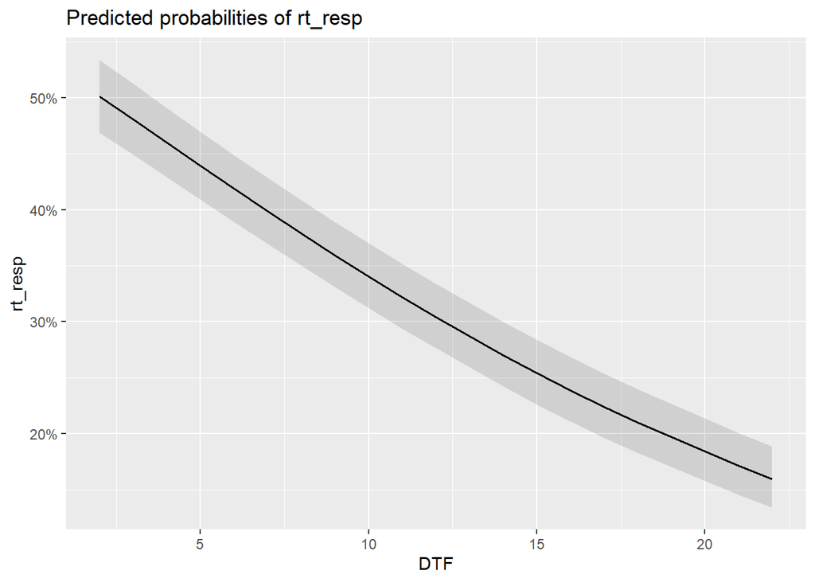

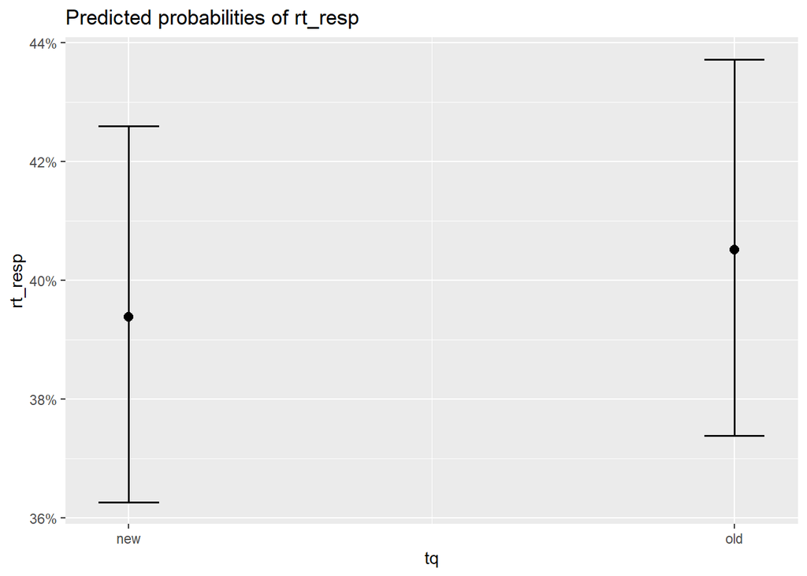

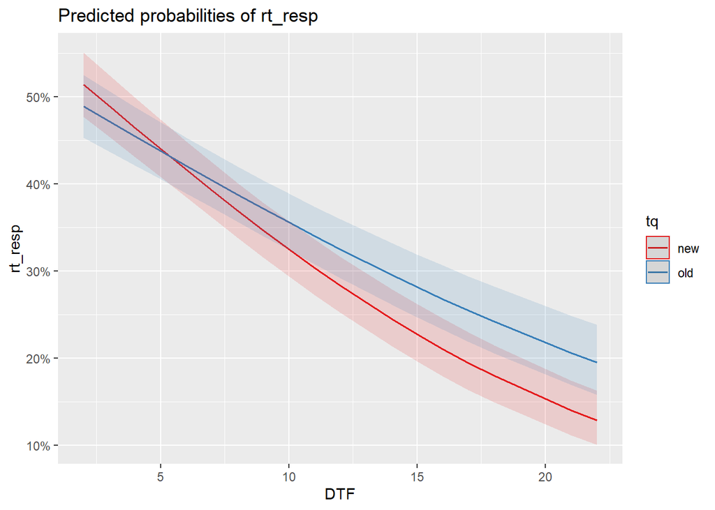

```
## Generalized linear mixed model fit by maximum likelihood (Laplace
##   Approximation) [glmerMod]
##  Family: binomial  ( logit )
## Formula: rt_resp ~ DTAF * tq + (1 | multichar_knowresp)
##    Data: tdlmm
##
##      AIC      BIC   logLik deviance df.resid
##   9214.5   9249.0  -4602.3   9204.5     7189
##
## Scaled residuals:
##     Min      1Q  Median      3Q     Max
## -1.9434 -0.8142 -0.5355  0.9881  3.4588
##
## Random effects:
##  Groups             Name        Variance Std.Dev.
##  multichar_knowresp (Intercept) 0.2716   0.5212
## Number of obs: 7194, groups:  multichar_knowresp, 84
##
## Fixed effects:
##             Estimate Std. Error z value Pr(>|z|)
## (Intercept)  1.69277    0.18541   9.130   <2e-16 ***
## DTAF        -0.16291    0.01360 -11.980   <2e-16 ***
## tqold       -0.35502    0.24395  -1.455    0.146
## DTAF:tqold   0.03010    0.01884   1.598    0.110
## ---
## Signif. codes:  0 '***' 0.001 '**' 0.01 '*' 0.05 '.' 0.1 ' ' 1
##
## Correlation of Fixed Effects:
##            (Intr) DTAF   tqold
## DTAF       -0.932
## tqold      -0.686  0.706
## DTAF:tqold  0.670 -0.720 -0.979
## optimizer (Nelder_Mead) convergence code: 0 (OK)
## Model failed to converge with max|grad| = 0.00549861 (tol = 0.002, component 1)
```

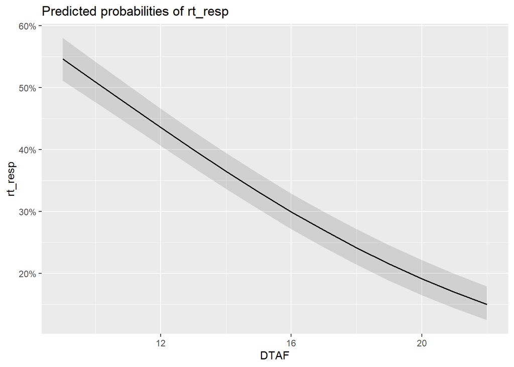

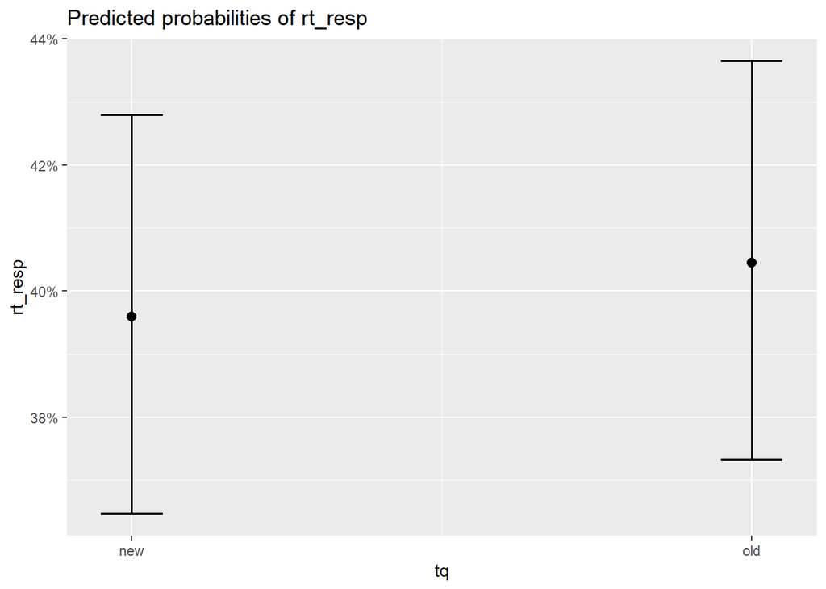

```
## Data were 'prettified'. Consider using `terms="DTAF [all]"` to get smooth plots.
```

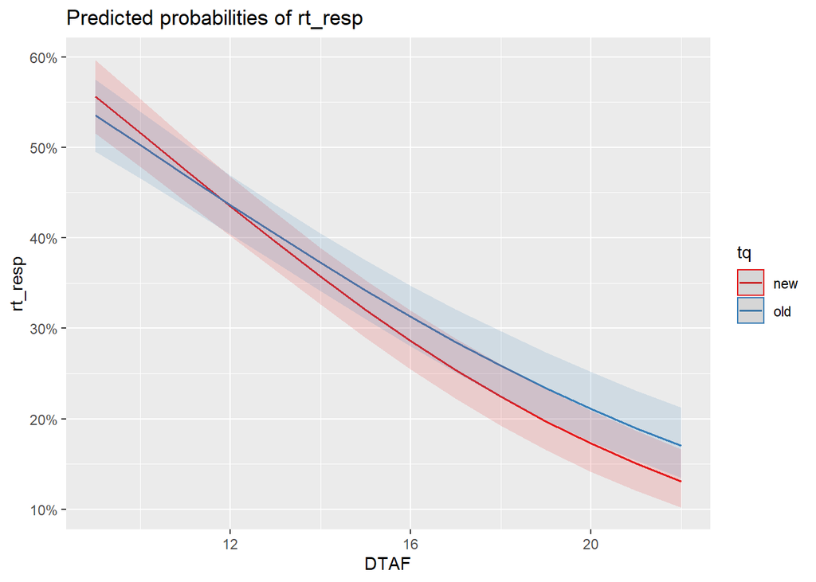

```
## Generalized linear mixed model fit by maximum likelihood (Laplace
##   Approximation) [glmerMod]
##  Family: binomial  ( logit )
## Formula: rt_resp ~ DTAN * tq + (1 | multichar_knowresp)
##    Data: tdlmm
##
##      AIC      BIC   logLik deviance df.resid
##   9271.3   9305.7  -4630.6   9261.3     7189
##
## Scaled residuals:
##     Min      1Q  Median      3Q     Max
## -2.0308 -0.8064 -0.5619  1.0042  2.8016
##
## Random effects:
##  Groups             Name        Variance Std.Dev.
##  multichar_knowresp (Intercept) 0.2667   0.5164
## Number of obs: 7194, groups:  multichar_knowresp, 84
##
## Fixed effects:
##             Estimate Std. Error z value Pr(>|z|)
## (Intercept)  2.34605    0.26054   9.005   <2e-16 ***
## DTAN        -0.21592    0.01986 -10.870   <2e-16 ***
## tqold       -0.43111    0.35353  -1.219    0.223
## DTAN:tqold   0.03749    0.02760   1.358    0.174
## ---
## Signif. codes:  0 '***' 0.001 '**' 0.01 '*' 0.05 '.' 0.1 ' ' 1
##
## Correlation of Fixed Effects:
##            (Intr) DTAN   tqold
## DTAN       -0.966
## tqold      -0.701  0.711
## DTAN:tqold  0.694 -0.718 -0.990
## optimizer (Nelder_Mead) convergence code: 0 (OK)
## Model failed to converge with max|grad| = 0.00270251 (tol = 0.002, component 1)
```

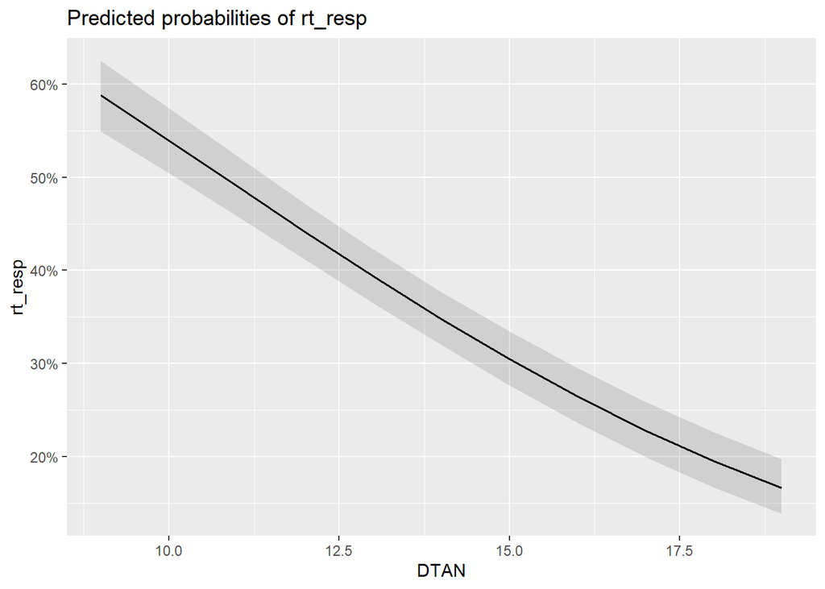

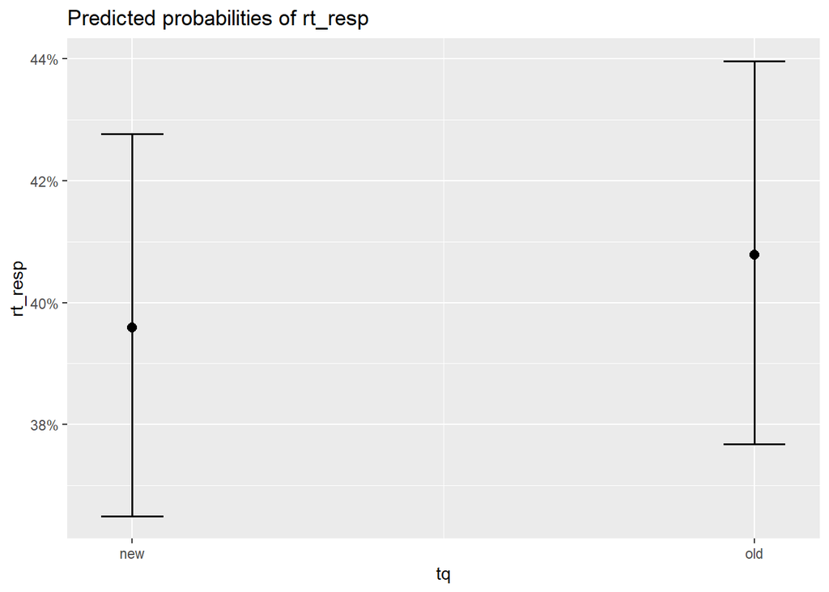

```
## Data were 'prettified'. Consider using `terms="DTAN [all]"` to get smooth plots.
```

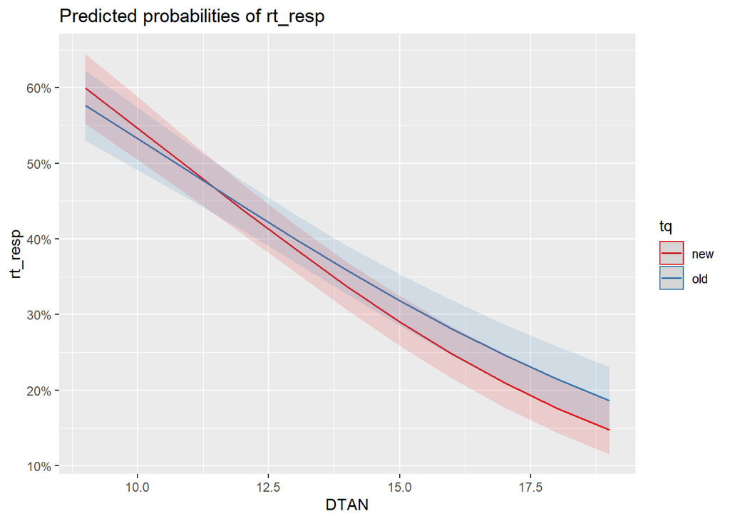

|  | rt_resp |  |  |  | rt_resp |  |  |  | rt_resp |  |  |  |
| --- | --- | --- | --- | --- | --- | --- | --- | --- | --- | --- | --- | --- |
| Predictors | Log-Odds | std. Error | CI | p | Log-Odds | std. Error | CI | p | Log-Odds | std. Error | CI | p |
| (Intercept) | 0.25 | 0.08 | 0.09 – 0.42 | **0.003** | 1.69 | 0.19 | 1.33 – 2.06 | **<0.001** | 2.35 | 0.26 | 1.84 – 2.86 | **<0.001** |
| DTF | -0.10 | 0.01 | -0.11 – -0.08 | **<0.001** |  |  |  |  |  |  |  |  |
| tq [old] | -0.16 | 0.08 | -0.32 – 0.00 | 0.056 | -0.36 | 0.24 | -0.83 – 0.12 | 0.146 | -0.43 | 0.35 | -1.12 – 0.26 | 0.223 |
| DTF * tq [old] | 0.03 | 0.01 | 0.01 – 0.05 | **0.005** |  |  |  |  |  |  |  |  |
| DTAF |  |  |  |  | -0.16 | 0.01 | -0.19 – -0.14 | **<0.001** |  |  |  |  |
| DTAF * tq [old] |  |  |  |  | 0.03 | 0.02 | -0.01 – 0.07 | 0.110 |  |  |  |  |
| DTAN |  |  |  |  |  |  |  |  | -0.22 | 0.02 | -0.25 – -0.18 | **<0.001** |
| DTAN * tq [old] |  |  |  |  |  |  |  |  | 0.04 | 0.03 | -0.02 – 0.09 | 0.174 |
| Random Effects |  |  |  |  |  |  |  |  |  |  |  |  |
| σ<sup>2</sup> | 3.29 |  |  |  | 3.29 |  |  |  | 3.29 |  |  |  |
| τ<sub>00</sub> | 0.27 <sub>multichar_knowresp</sub> |  |  |  | 0.27 <sub>multichar_knowresp</sub> |  |  |  | 0.27 <sub>multichar_knowresp</sub> |  |  |  |
| ICC | 0.08 |  |  |  | 0.08 |  |  |  | 0.07 |  |  |  |
| N | 84 <sub>multichar_knowresp</sub> |  |  |  | 84 <sub>multichar_knowresp</sub> |  |  |  | 84 <sub>multichar_knowresp</sub> |  |  |  |
| Observations | 7194 |  |  |  | 7194 |  |  |  | 7194 |  |  |  |
| Marginal R<sup>2</sup> / Conditional R<sup>2</sup> | 0.055 / 0.127 |  |  |  | 0.051 / 0.124 |  |  |  | 0.039 / 0.111 |  |  |  |
| AIC | 9201.496 |  |  |  | 9214.550 |  |  |  | 9271.258 |  |  |  |
| AICc | 9201.504 |  |  |  | 9214.558 |  |  |  | 9271.266 |  |  |  |

### Models #2 - with random slope (trial quality)

Logistic mixed regression for the test phase. Does difference from prototypes or familiarity/novelty have an effect on correct categorization in the test phase?

```
## Generalized linear mixed model fit by maximum likelihood (Laplace
##   Approximation) [glmerMod]
##  Family: binomial  ( logit )
## Formula: rt_resp ~ DTF * tq + (tq | multichar_knowresp)
##    Data: tdlmm
## Control: lmerControl(optCtrl = list(xtol_abs = 1e-08, ftol_abs = 1e-08,
##     maxeval = 1e+05))
##
##      AIC      BIC   logLik deviance df.resid
##   9203.7   9251.9  -4594.9   9189.7     7187
##
## Scaled residuals:
##     Min      1Q  Median      3Q     Max
## -1.9776 -0.8155 -0.5278  0.9809  3.8391
##
## Random effects:
##  Groups             Name        Variance Std.Dev. Corr
##  multichar_knowresp (Intercept) 0.30488  0.5522
##                     tqold       0.04219  0.2054   -0.36
## Number of obs: 7194, groups:  multichar_knowresp, 84
##
## Fixed effects:
##              Estimate Std. Error z value Pr(>|z|)
## (Intercept)  0.253786   0.086040   2.950  0.00318 **
## DTF         -0.098886   0.007848 -12.601  < 2e-16 ***
## tqold       -0.161091   0.086644  -1.859  0.06300 .
## DTF:tqold    0.030344   0.010584   2.867  0.00414 **
## ---
## Signif. codes:  0 '***' 0.001 '**' 0.01 '*' 0.05 '.' 0.1 ' ' 1
##
## Correlation of Fixed Effects:
##           (Intr) DTF    tqold
## DTF       -0.574
## tqold     -0.569  0.569
## DTF:tqold  0.425 -0.742 -0.769
## optimizer (nloptwrap) convergence code: 0 (OK)
## Model failed to converge with max|grad| = 0.0020772 (tol = 0.002, component 1)
```

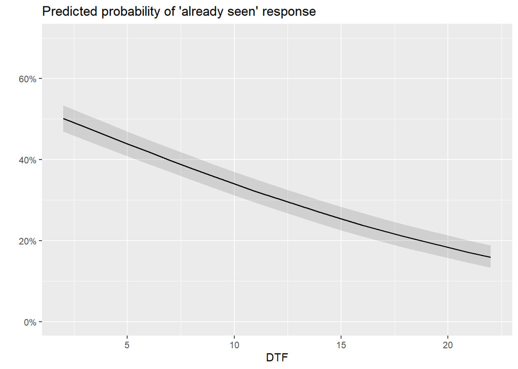

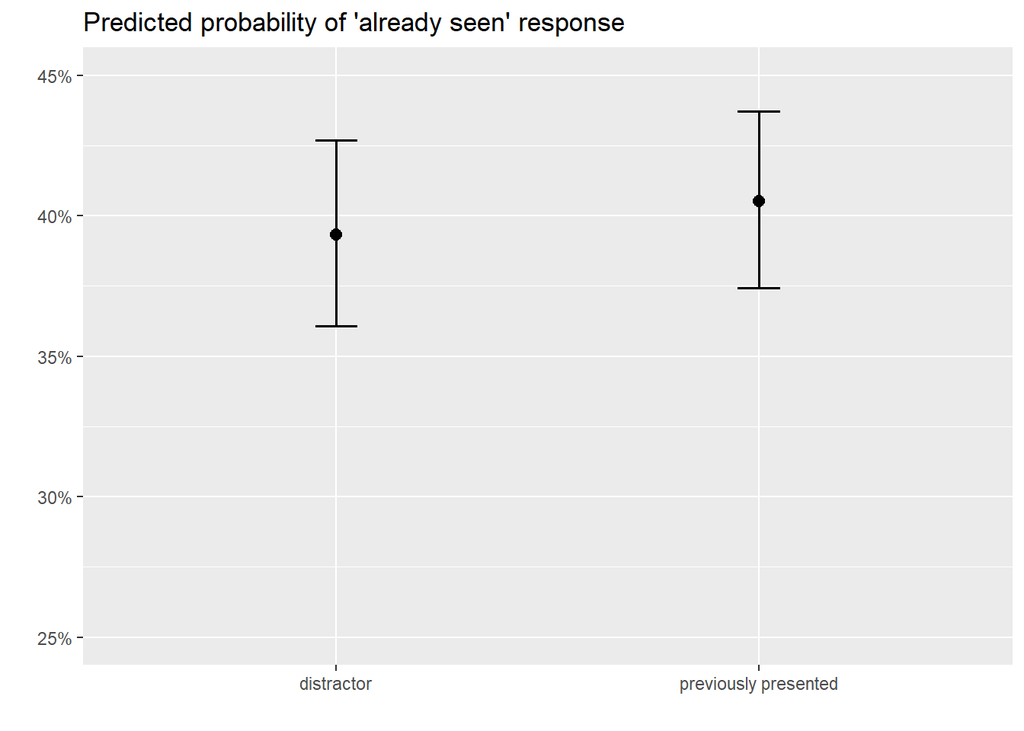

```
## which will replace the existing scale.
```

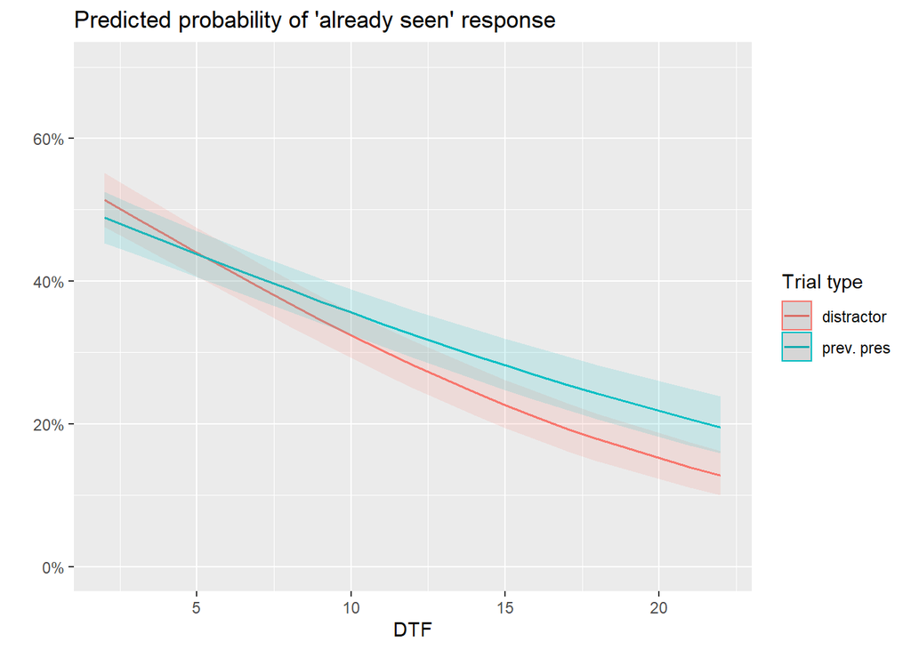

```
## Generalized linear mixed model fit by maximum likelihood (Laplace
##   Approximation) [glmerMod]
##  Family: binomial  ( logit )
## Formula: rt_resp ~ DTAF * tq + (tq | multichar_knowresp)
##    Data: tdlmm
##
##      AIC      BIC   logLik deviance df.resid
##   9216.9   9265.1  -4601.4   9202.9     7187
##
## Scaled residuals:
##     Min      1Q  Median      3Q     Max
## -1.9905 -0.8134 -0.5361  0.9876  3.5340
##
## Random effects:
##  Groups             Name        Variance Std.Dev. Corr
##  multichar_knowresp (Intercept) 0.30000  0.5477
##                     tqold       0.04123  0.2031   -0.33
## Number of obs: 7194, groups:  multichar_knowresp, 84
##
## Fixed effects:
##             Estimate Std. Error z value Pr(>|z|)
## (Intercept)  1.70132    0.18707   9.095   <2e-16 ***
## DTAF        -0.16374    0.01367 -11.979   <2e-16 ***
## tqold       -0.36383    0.24593  -1.479    0.139
## DTAF:tqold   0.03095    0.01893   1.635    0.102
## ---
## Signif. codes:  0 '***' 0.001 '**' 0.01 '*' 0.05 '.' 0.1 ' ' 1
##
## Correlation of Fixed Effects:
##            (Intr) DTAF   tqold
## DTAF       -0.927
## tqold      -0.692  0.705
## DTAF:tqold  0.669 -0.722 -0.974
```

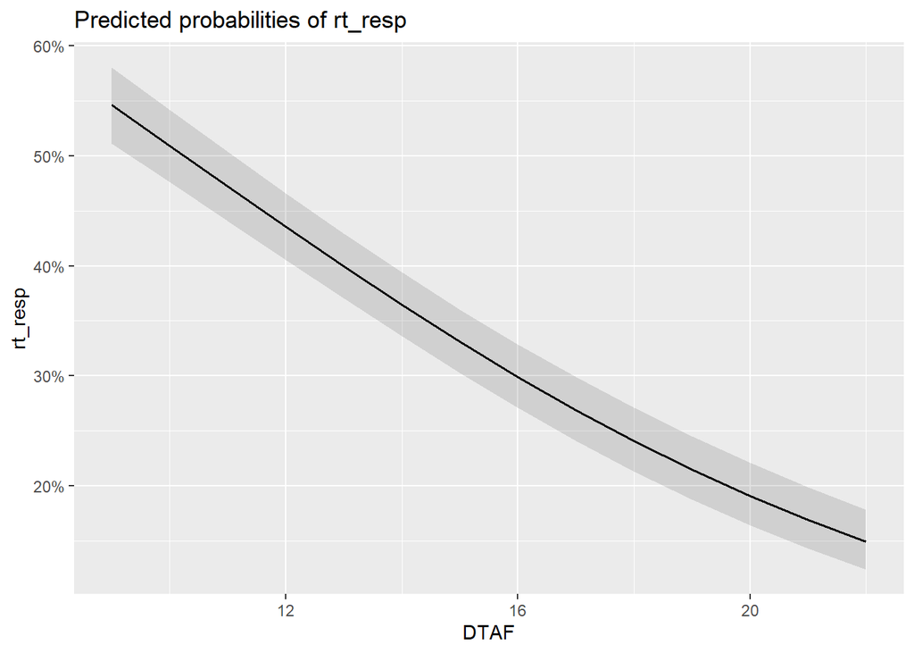

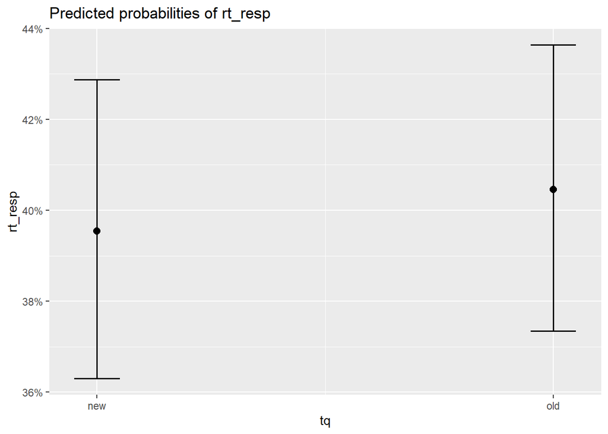

```
## Data were 'prettified'. Consider using `terms="DTAF [all]"` to get smooth plots.
```

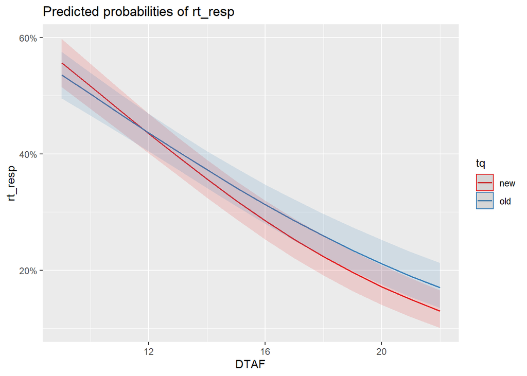

```
## Generalized linear mixed model fit by maximum likelihood (Laplace
##   Approximation) [glmerMod]
##  Family: binomial  ( logit )
## Formula: rt_resp ~ DTAN * tq + (tq | multichar_knowresp)
##    Data: tdlmm
##
##      AIC      BIC   logLik deviance df.resid
##   9273.7   9321.9  -4629.9   9259.7     7187
##
## Scaled residuals:
##     Min      1Q  Median      3Q     Max
## -2.0670 -0.8054 -0.5595  1.0031  2.7840
##
## Random effects:
##  Groups             Name        Variance Std.Dev. Corr
##  multichar_knowresp (Intercept) 0.29205  0.5404
##                     tqold       0.04003  0.2001   -0.31
## Number of obs: 7194, groups:  multichar_knowresp, 84
##
## Fixed effects:
##             Estimate Std. Error z value Pr(>|z|)
## (Intercept)  2.35772    0.26207   8.997   <2e-16 ***
## DTAN        -0.21698    0.01995 -10.876   <2e-16 ***
## tqold       -0.44254    0.35535  -1.245    0.213
## DTAN:tqold   0.03854    0.02771   1.391    0.164
## ---
## Signif. codes:  0 '***' 0.001 '**' 0.01 '*' 0.05 '.' 0.1 ' ' 1
##
## Correlation of Fixed Effects:
##            (Intr) DTAN   tqold
## DTAN       -0.964
## tqold      -0.704  0.711
## DTAN:tqold  0.694 -0.720 -0.988
## optimizer (Nelder_Mead) convergence code: 0 (OK)
## Model failed to converge with max|grad| = 0.00890679 (tol = 0.002, component 1)
```

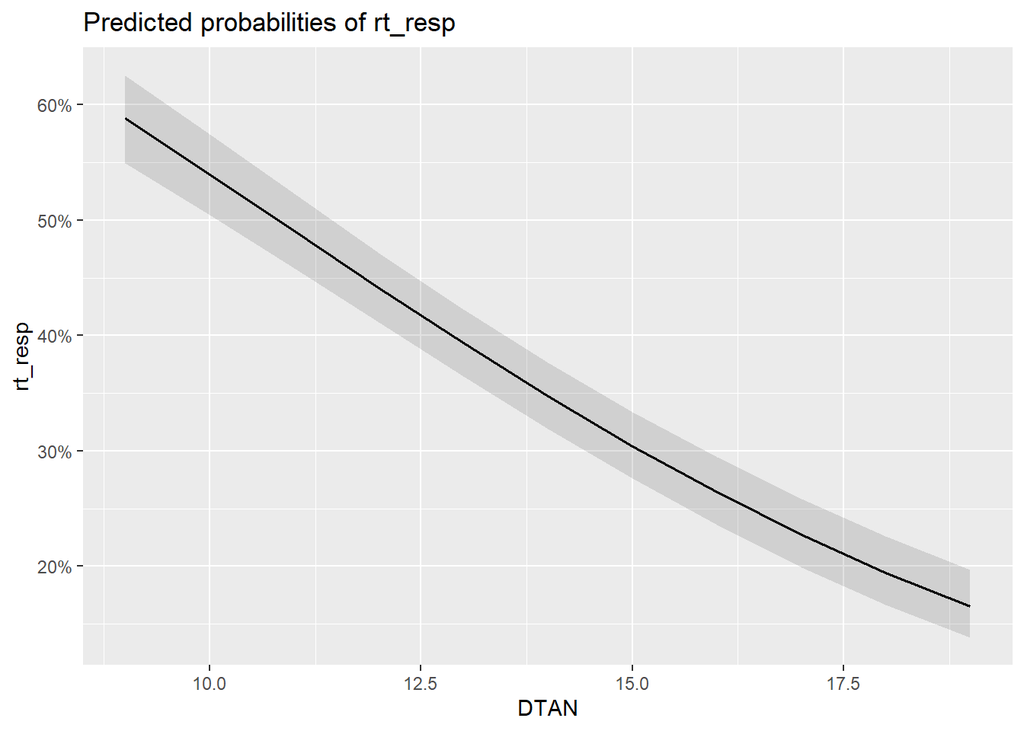

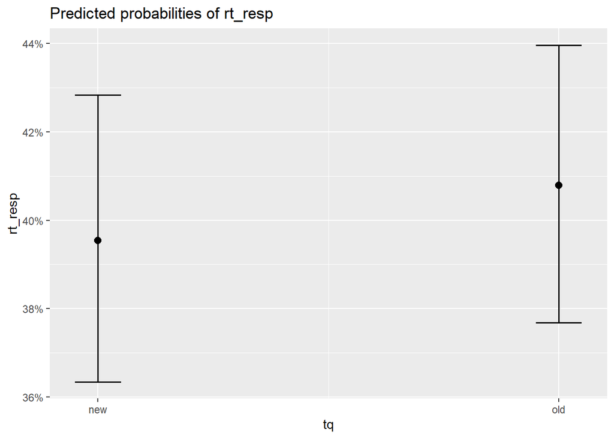

```
## Data were 'prettified'. Consider using `terms="DTAN [all]"` to get smooth plots.
```

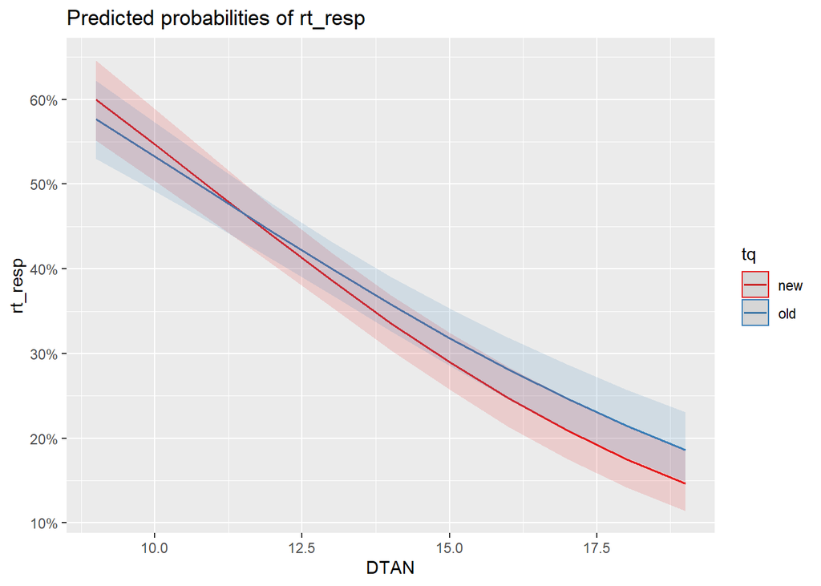

|  | rt_resp |  |  |  | rt_resp |  |  |  | rt_resp |  |  |  |
| --- | --- | --- | --- | --- | --- | --- | --- | --- | --- | --- | --- | --- |
| Predictors | Log-Odds | std. Error | CI | p | Log-Odds | std. Error | CI | p | Log-Odds | std. Error | CI | p |
| (Intercept) | 0.25 | 0.09 | 0.09 – 0.42 | **0.003** | 1.70 | 0.19 | 1.33 – 2.07 | **<0.001** | 2.36 | 0.26 | 1.84 – 2.87 | **<0.001** |
| DTF | -0.10 | 0.01 | -0.11 – -0.08 | **<0.001** |  |  |  |  |  |  |  |  |
| tq [old] | -0.16 | 0.09 | -0.33 – 0.01 | 0.063 | -0.36 | 0.25 | -0.85 – 0.12 | 0.139 | -0.44 | 0.36 | -1.14 – 0.25 | 0.213 |
| DTF * tq [old] | 0.03 | 0.01 | 0.01 – 0.05 | **0.004** |  |  |  |  |  |  |  |  |
| DTAF |  |  |  |  | -0.16 | 0.01 | -0.19 – -0.14 | **<0.001** |  |  |  |  |
| DTAF * tq [old] |  |  |  |  | 0.03 | 0.02 | -0.01 – 0.07 | 0.102 |  |  |  |  |
| DTAN |  |  |  |  |  |  |  |  | -0.22 | 0.02 | -0.26 – -0.18 | **<0.001** |
| DTAN * tq [old] |  |  |  |  |  |  |  |  | 0.04 | 0.03 | -0.02 – 0.09 | 0.164 |
| Random Effects |  |  |  |  |  |  |  |  |  |  |  |  |
| σ<sup>2</sup> | 3.29 |  |  |  | 3.29 |  |  |  | 3.29 |  |  |  |
| τ<sub>00</sub> | 0.30 <sub>multichar_knowresp</sub> |  |  |  | 0.30 <sub>multichar_knowresp</sub> |  |  |  | 0.29 <sub>multichar_knowresp</sub> |  |  |  |
| τ<sub>11</sub> | 0.04 <sub>multichar_knowresp.tqold</sub> |  |  |  | 0.04 <sub>multichar_knowresp.tqold</sub> |  |  |  | 0.04 <sub>multichar_knowresp.tqold</sub> |  |  |  |
| ρ<sub>01</sub> | -0.36 <sub>multichar_knowresp</sub> |  |  |  | -0.33 <sub>multichar_knowresp</sub> |  |  |  | -0.31 <sub>multichar_knowresp</sub> |  |  |  |
| ICC | 0.08 |  |  |  | 0.08 |  |  |  | 0.08 |  |  |  |
| N | 84 <sub>multichar_knowresp</sub> |  |  |  | 84 <sub>multichar_knowresp</sub> |  |  |  | 84 <sub>multichar_knowresp</sub> |  |  |  |
| Observations | 7194 |  |  |  | 7194 |  |  |  | 7194 |  |  |  |
| Marginal R<sup>2</sup> / Conditional R<sup>2</sup> | 0.055 / 0.131 |  |  |  | 0.051 / 0.127 |  |  |  | 0.039 / 0.114 |  |  |  |
| AIC | 9203.704 |  |  |  | 9216.892 |  |  |  | 9273.710 |  |  |  |
| AICc | 9203.719 |  |  |  | 9216.908 |  |  |  | 9273.726 |  |  |  |